# Corona prepping using Finnish data regression using OLS regression and the Potential for Change Index (PCI)

## Main question: at this point we're interested in one single regression, i.e. **what predicts whether people do maskless contacts with non-householders**

[Research Document](https://docs.google.com/document/d/1iLciHcvVvf8QwFS7wiyNBevpD1B9yDRqMlM4_oCcVcA/edit?usp=sharing)

[Questions codebook](https://docs.google.com/document/d/1YZVCP1UNxnNLAK2kYDfA9Y98leTZYurZD-d8iByhdi0/edit?usp=sharing)

[Method of delivery](https://docs.google.com/document/d/1G1JT9JUJrTK3aaXXuRawYACJaGNxU7mcXL9i-d8eKXY/edit)

```python
import pandas as pd
import numpy as np
import seaborn as sns
import matplotlib.pyplot as plt
import session_info

from ml_class import (plot_cv_indices,
                      plot_decision_boundary,
                     plot_learning_curve,
                     multi_roc_auc_plot,
                     dict_of_models,
                     RFE_opt_rf,
                     make_confusion_matrix,
                     summary_performance_metrics_classification)

from sklearn.metrics import mean_squared_error
from sklearn.model_selection import KFold, GroupKFold, GroupShuffleSplit, RepeatedStratifiedKFold, RepeatedKFold
# from sklearn.impute import IterativeImputer
```

```python
from sklearn.model_selection import train_test_split, GridSearchCV
from scipy import stats
# from sklearn.feature_selection import RFE, RFECV
```

```python
from sklearn.model_selection import RepeatedStratifiedKFold, cross_val_score, cross_validate
# from sklearn.ensemble import BaggingClassifier, BaggingRegressor
# from imblearn.ensemble import BalancedBaggingClassifier
from sklearn.linear_model import LinearRegression
```

```python
from sklearn.model_selection import KFold
```

```python
import statsmodels.api as sm
```

```python
from jmspack.frequentist_statistics import (correlation_analysis,
                                            potential_for_change_index,
                                            multiple_univariate_OLSs
                                           )
from jmspack.utils import (flatten,
                           apply_scaling,
                           JmsColors
                          )
```

```python
_ = sns.set_style("whitegrid")
```

### Virtual Environments and Packages

```python
session_info.show(req_file_name="corona_preppers-requirements.txt",
      write_req_file=False) #add write_req_file=True to function to get requirements.txt file of packages used
```

**Click to view session information**

```
-----
jmspack             0.1.0
matplotlib          3.4.3
ml_class            NA
numpy               1.21.4
pandas              1.3.4
scipy               1.7.2
seaborn             0.11.2
session_info        1.0.0
sklearn             1.0.1
statsmodels         0.13.1
-----
```

**Click to view modules imported as dependencies**

[output not shown]

[output cut: 20 more lines]

[output not shown]

```
-----
IPython             7.29.0
jupyter_client      7.0.6
jupyter_core        4.9.1
jupyterlab          3.2.3
notebook            6.4.5
-----
Python 3.8.12 | packaged by conda-forge | (default, Oct 12 2021, 21:50:38) [Clang 11.1.0 ]
macOS-10.15.7-x86_64-i386-64bit
-----
Session information updated at 2021-11-26 10:34
```

### Read in data, show info and data head

```python
df = pd.read_csv("data/shield_gjames_21-09-20_prepped.csv").drop("Unnamed: 0", axis=1)
```

```python
df.head()
```

|  | id | sampling_weight | demographic_gender | demographic_age | demographic_4_areas | demographic_8_areas | demographic_higher_education | behaviour_indoors_nonhouseholders | behaviour_close_contact | behaviour_quarantined | ... | intention_public_transport_recoded | intention_indoor_meeting_recoded | intention_restaurant_recoded | intention_pa_recoded | intention_composite | behaviour_indoors_nonhouseholders_recoded | behaviour_unmasked_recoded | behavior_composite | behavior_composite_recoded | intention_behavior_composite |
| --- | --- | --- | --- | --- | --- | --- | --- | --- | --- | --- | --- | --- | --- | --- | --- | --- | --- | --- | --- | --- | --- |
| 0 | 1 | 2.060959 | 2 | 60+ | 2 | 7 | 0 | 2 | 5 | 2 | ... | 0 | 0 | 0 | 0 | 0 | 1.000000 | 0.000000 | 0.000000 | 0.000000 | 0.000000 |
| 1 | 2 | 1.784139 | 2 | 40-49 | 1 | 1 | 1 | 3 | 3 | 2 | ... | 0 | 1 | 1 | 1 | 3 | 0.785714 | 0.214286 | 0.168367 | 0.841837 | 1.920918 |
| 2 | 3 | 1.204000 | 1 | 60+ | 1 | 2 | 1 | 4 | 4 | 2 | ... | 0 | 0 | 0 | 0 | 0 | 0.500000 | 0.214286 | 0.107143 | 0.535714 | 0.267857 |
| 3 | 4 | 2.232220 | 1 | 60+ | 2 | 6 | 0 | 4 | 3 | 2 | ... | 0 | 2 | 0 | 2 | 4 | 0.500000 | 0.500000 | 0.250000 | 1.250000 | 2.625000 |
| 4 | 5 | 1.627940 | 2 | 18-29 | 1 | 3 | 0 | 6 | 3 | 2 | ... | 0 | 2 | 0 | 0 | 2 | 0.000000 | 0.214286 | 0.000000 | 0.000000 | 1.000000 |

5 rows × 106 columns

```python
sdt_columns = df.filter(regex="sdt").columns.tolist()
```

```python
drop_sdt = True
if drop_sdt:
    df=df.drop(sdt_columns, axis=1)
```

```python
df.shape
```

```
(2272, 87)
```

### Specify the feature list, grouping variable, and specify the grouping variable as a categorical variable

```python
target = "intention_behavior_composite"
```

```python
df[target] = (df[target] - 10) * -1
```

```python
features_list = df.filter(regex="^automaticity|attitude|^norms|^risk|^effective").columns.tolist()
```

## EDA on the target

Check the amount of samples in the target

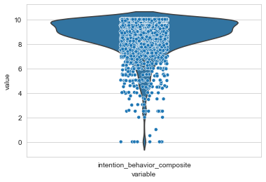

```python
_ = sns.violinplot(data=df[[target]].melt(),
                    x="variable",
                    y="value"
               )
_ = sns.stripplot(data=df[[target]].melt(),
                    x="variable",
                    y="value",
                  edgecolor='white',
                  linewidth=0.5
               )
```

```python
pd.crosstab(df["demographic_gender"], df["demographic_age"])
```

| demographic_age demographic_gender | 18-29 | 30-39 | 40-49 | 50-59 | 60+ |
| --- | --- | --- | --- | --- | --- |
| 1 | 114 | 169 | 187 | 168 | 337 |
| 2 | 281 | 185 | 229 | 211 | 391 |

```python
target_df = df[target]
target_df.describe().to_frame().T
```

|  | count | mean | std | min | 25% | 50% | 75% | max |
| --- | --- | --- | --- | --- | --- | --- | --- | --- |
| intention_behavior_composite | 2272.0 | 8.582428 | 1.524704 | -0.0 | 8.017857 | 8.964286 | 9.5 | 10.0 |

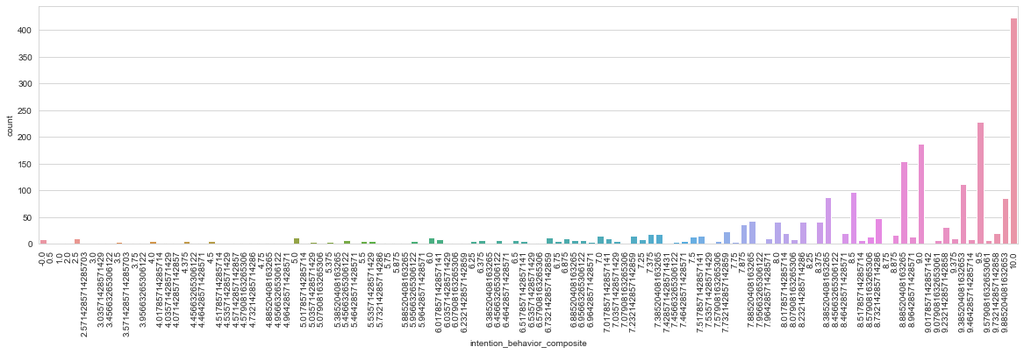

```python
_ = plt.figure(figsize=(20, 5))
_ = sns.countplot(x=target_df)
_ = plt.xticks(rotation=90)
```

```python
df = (df[["demographic_age", "demographic_higher_education"] + features_list + [target]]
#  .drop(drop_list, axis=1)
#  .assign(target = target_df)
#       .dropna(axis=0)
)
```

```python
df.info()
```

```
<class 'pandas.core.frame.DataFrame'>
RangeIndex: 2272 entries, 0 to 2271
Data columns (total 30 columns):
 #   Column                            Non-Null Count  Dtype
---  ------                            --------------  -----
 0   demographic_age                   2272 non-null   object
 1   demographic_higher_education      2272 non-null   int64
 2   automaticity_carry_mask           2272 non-null   int64
 3   automaticity_put_on_mask          2272 non-null   int64
 4   inst_attitude_protects_self       2272 non-null   int64
 5   inst_attitude_protects_others     2272 non-null   int64
 6   inst_attitude_sense_of_community  2272 non-null   int64
 7   inst_attitude_enough_oxygen       2272 non-null   int64
 8   inst_attitude_no_needless_waste   2272 non-null   int64
 9   norms_family_friends              2272 non-null   int64
```

[output cut: 22 more lines]

```python
display(df[target].value_counts().head().to_frame()), df.shape[0], df[target].value_counts().head().sum()
```

|  | intention_behavior_composite |
| --- | --- |
| 10.000000 | 424 |
| 9.500000 | 228 |
| 9.000000 | 187 |
| 8.885204 | 155 |
| 9.385204 | 112 |

```
(None, 2272, 1106)
```

## Correlations between features and target

```python
dict_results = correlation_analysis(df,
                                    row_list=[target],
                                    col_list=features_list,
                                    # method='pearson',
                                    check_norm=True,
                                    dropna='pairwise')
```

```python
corrs_df = dict_results["summary"].sort_values(by="r-value", ascending=False)
corrs_df.head(5)
```

|  | analysis | feature1 | feature2 | r-value | p-value | stat-sign | N |
| --- | --- | --- | --- | --- | --- | --- | --- |
| 10 | Spearman Rank | norms_people_present_indoors | intention_behavior_composite | 0.417490 | 1.573553e-96 | True | 2272 |
| 17 | Spearman Rank | effective_means_masks | intention_behavior_composite | 0.398325 | 2.909620e-87 | True | 2272 |
| 0 | Spearman Rank | automaticity_carry_mask | intention_behavior_composite | 0.373645 | 3.383126e-76 | True | 2272 |
| 22 | Spearman Rank | risk_severity | intention_behavior_composite | 0.367338 | 1.609304e-73 | True | 2272 |
| 7 | Spearman Rank | norms_family_friends | intention_behavior_composite | 0.365861 | 6.684440e-73 | True | 2272 |

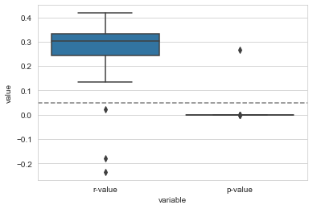

```python
_ = sns.boxplot(data=corrs_df[["r-value", "p-value"]].melt(),
                x="variable", y="value")
_ = plt.axhline(y=0.05, c="grey", ls="--")
```

```python
neg_corrs_features = corrs_df[corrs_df["r-value"] < 0].feature1.tolist()
```

```python
neg_corrs_features
```

```
['aff_attitude_difficult_breathing', 'risk_fear_restrictions']
```

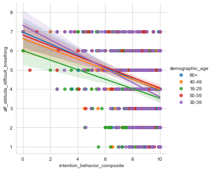

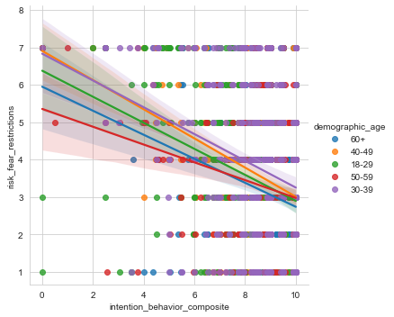

```python
for feature in neg_corrs_features:
    _ = sns.lmplot(data=df,
               x=target,
               y=feature,
               hue="demographic_age",
              legend=True)
```

## Multivariate Linear Regression

```python
X = df[features_list]
y = df[target]
```

```python
mod = sm.OLS(endog=y, exog=X)
res = mod.fit()
display(res.summary())
```

OLS Regression Results

| Dep. Variable: | intention_behavior_composite | R-squared (uncentered): | 0.980 |
| --- | --- | --- | --- |
| Model: | OLS | Adj. R-squared (uncentered): | 0.980 |
| Method: | Least Squares | F-statistic: | 4050. |
| Date: | Fri, 26 Nov 2021 | Prob (F-statistic): | 0.00 |
| Time: | 10:34:37 | Log-Likelihood: | -3705.8 |
| No. Observations: | 2272 | AIC: | 7466. |
| Df Residuals: | 2245 | BIC: | 7620. |
| Df Model: | 27 |  |  |
| Covariance Type: | nonrobust |  |  |

|  | coef | std err | t | P>\|t\| | [0.025 | 0.975] |
| --- | --- | --- | --- | --- | --- | --- |
| automaticity_carry_mask | 0.0923 | 0.031 | 2.933 | 0.003 | 0.031 | 0.154 |
| automaticity_put_on_mask | 0.0787 | 0.034 | 2.331 | 0.020 | 0.012 | 0.145 |
| inst_attitude_protects_self | -0.0120 | 0.024 | -0.491 | 0.624 | -0.060 | 0.036 |
| inst_attitude_protects_others | 0.2237 | 0.032 | 6.901 | 0.000 | 0.160 | 0.287 |
| inst_attitude_sense_of_community | -0.0035 | 0.020 | -0.173 | 0.863 | -0.043 | 0.036 |
| inst_attitude_enough_oxygen | 0.1177 | 0.021 | 5.668 | 0.000 | 0.077 | 0.158 |
| inst_attitude_no_needless_waste | 0.0190 | 0.016 | 1.172 | 0.241 | -0.013 | 0.051 |
| norms_family_friends | 0.0758 | 0.027 | 2.840 | 0.005 | 0.023 | 0.128 |
| norms_risk_groups | -4.061e-05 | 0.034 | -0.001 | 0.999 | -0.067 | 0.067 |
| norms_officials | 0.1520 | 0.032 | 4.817 | 0.000 | 0.090 | 0.214 |
| norms_people_present_indoors | 0.1691 | 0.024 | 7.160 | 0.000 | 0.123 | 0.215 |
| aff_attitude_comfortable | 0.0224 | 0.029 | 0.778 | 0.437 | -0.034 | 0.079 |
| aff_attitude_calm | 0.0316 | 0.027 | 1.192 | 0.233 | -0.020 | 0.084 |
| aff_attitude_safe | 0.0213 | 0.031 | 0.688 | 0.492 | -0.039 | 0.082 |
| aff_attitude_responsible | 0.0120 | 0.033 | 0.363 | 0.717 | -0.053 | 0.077 |
| aff_attitude_difficult_breathing | 0.1773 | 0.019 | 9.375 | 0.000 | 0.140 | 0.214 |
| effective_means_handwashing | 0.0465 | 0.021 | 2.170 | 0.030 | 0.004 | 0.089 |
| effective_means_masks | 0.0202 | 0.028 | 0.721 | 0.471 | -0.035 | 0.075 |
| effective_means_distance | 0.1063 | 0.026 | 4.127 | 0.000 | 0.056 | 0.157 |
| effective_means_ventilation | 0.0497 | 0.020 | 2.507 | 0.012 | 0.011 | 0.089 |
| risk_likely_contagion | 0.0551 | 0.023 | 2.344 | 0.019 | 0.009 | 0.101 |
| risk_contagion_absent_protection | 0.0012 | 0.020 | 0.062 | 0.951 | -0.038 | 0.040 |
| risk_severity | 0.1452 | 0.021 | 6.893 | 0.000 | 0.104 | 0.187 |
| risk_fear_spread | 0.0224 | 0.026 | 0.848 | 0.396 | -0.029 | 0.074 |
| risk_fear_contagion_self | -0.0313 | 0.026 | -1.206 | 0.228 | -0.082 | 0.020 |
| risk_fear_contagion_others | -0.0046 | 0.025 | -0.185 | 0.853 | -0.053 | 0.044 |
| risk_fear_restrictions | 0.0210 | 0.014 | 1.451 | 0.147 | -0.007 | 0.049 |

| Omnibus: | 288.080 | Durbin-Watson: | 1.928 |
| --- | --- | --- | --- |
| Prob(Omnibus): | 0.000 | Jarque-Bera (JB): | 1109.978 |
| Skew: | -0.581 | Prob(JB): | 9.36e-242 |
| Kurtosis: | 6.221 | Cond. No. | 45.1 |

Notes:  
[1] R² is computed without centering (uncentered) since the model does not contain a constant.  
[2] Standard Errors assume that the covariance matrix of the errors is correctly specified.

## Multiple univariate regressions

```python
all_coefs_df = multiple_univariate_OLSs(X=X, y=y, features_list=features_list)
```

```python
all_coefs_df.sort_values("rsquared_adj", ascending=False).head(5)
```

|  | coef | std err | t | P>\|t\| | [0.025 | 0.975] | rsquared | rsquared_adj |
| --- | --- | --- | --- | --- | --- | --- | --- | --- |
| automaticity_put_on_mask | 0.4652 | 0.016 | 29.656 | 0.0 | 0.434 | 0.496 | 0.279246 | 0.278928 |
| automaticity_carry_mask | 0.4463 | 0.015 | 29.076 | 0.0 | 0.416 | 0.476 | 0.271358 | 0.271037 |
| effective_means_masks | 0.4922 | 0.017 | 28.986 | 0.0 | 0.459 | 0.526 | 0.270137 | 0.269816 |
| inst_attitude_protects_others | 0.5895 | 0.023 | 25.875 | 0.0 | 0.545 | 0.634 | 0.227764 | 0.227423 |
| norms_people_present_indoors | 0.4811 | 0.019 | 25.760 | 0.0 | 0.444 | 0.518 | 0.226196 | 0.225855 |

```python
top_feature = all_coefs_df.sort_values("rsquared_adj").tail(1).iloc[0].name
```

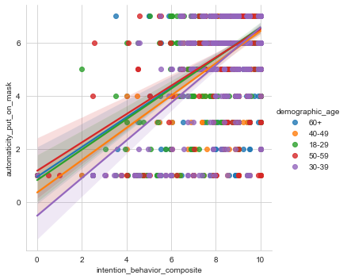

```python
_ = sns.lmplot(data=df,
               x=target,
               y=top_feature,
               hue="demographic_age",
              legend=True)
```

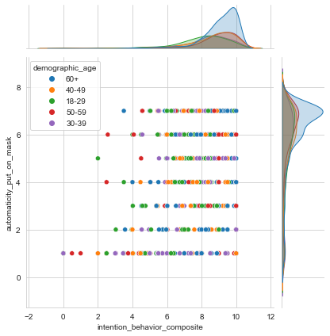

```python
ax = sns.jointplot(data=df,
                  x=target,
                  y=top_feature,
                  hue="demographic_age",
                  # kind="reg",
                   legend=True
                 )
# _ = ax._legend.remove()
```

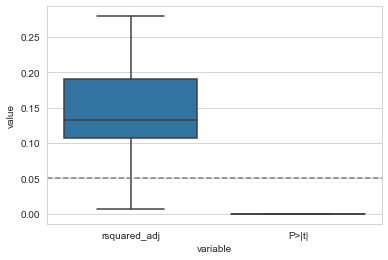

```python
_ = sns.boxplot(data=all_coefs_df[["rsquared_adj", "P>|t|"]].melt(),
                x="variable", y="value")
_ = plt.axhline(y=0.05, c="grey", ls="--")
```

```python
mod = sm.OLS(endog=y, exog=X[[top_feature]])
res = mod.fit()
```

```python
y_pred = res.predict(exog = X[[top_feature]])

df_test = pd.DataFrame({"y_pred": y_pred, target: y})

user_ids_first = df_test.head(1).index.tolist()[0]
user_ids_last = df_test.tail(1).index.tolist()[0]

plot_title="All"
```

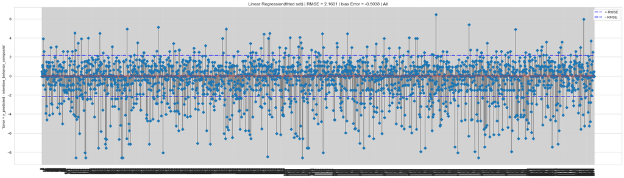

```python
_ = plt.figure(figsize=(30,8))
_ = plt.title(f"Linear Regression(fitted set) | RMSE = {round(np.sqrt(mean_squared_error(df_test['y_pred'], df_test[target])),4)} | bias Error = {round(np.mean(df_test['y_pred'] - df_test[target]), 4)} | {plot_title}")
rmse_plot = plt.stem(df_test.index, df_test['y_pred'] - df_test[target], use_line_collection=True, linefmt='grey', markerfmt='D')
_ = plt.hlines(y=round(np.sqrt(mean_squared_error(df_test['y_pred'], df_test[target])),2), colors='b', linestyles='-.', label='+ RMSE',
               xmin = user_ids_first,
               xmax = user_ids_last
              )
_ = plt.hlines(y=round(-np.sqrt(mean_squared_error(df_test['y_pred'], df_test[target])),2), colors='b', linestyles='-.', label='- RMSE',
               xmin = user_ids_first,
               xmax = user_ids_last
              )
_ = plt.xticks(rotation=90, ticks=df_test.index)
_ = plt.ylabel(f"'Error = y_predicted - {target}'")
# _ = plt.ylim([(df_test['y_pred'] - df_test[grouping_var]).min(),
#               (df_test['y_pred'] - df_test[grouping_var]).max()])
_ = plt.legend()
_ = plt.show()
```

```python
groups_dict = {"18 - 39": ['18-29','30-39'],
              "40 - 59": ['40-49', '50-59'],
              "60+": ['60+'],
              "All": ['60+', '40-49', '18-29', '50-59', '30-39'],
              "Lower Education": 0,
              "Higher Education": 1}
```

```python
# tmp_ols_df[["coef", "P>|t|", "rsquared", "rsquared_adj"]]
```

```python
all_ols_df = pd.DataFrame()
for group in groups_dict:
    if type(groups_dict[group]) == list:
        tmp_df = df[df["demographic_age"].isin(groups_dict[group])]
    else:
        tmp_df = df[df["demographic_higher_education"] == groups_dict[group]]

    tmp_X = tmp_df[features_list]
    tmp_y = tmp_df[target]

    tmp_ols_df = multiple_univariate_OLSs(X=tmp_X,
                                          y=tmp_y,
                                          features_list=features_list)[["coef", "P>|t|", "rsquared_adj"]]
    tmp_ols_df.columns = pd.MultiIndex.from_tuples([(group, x) for x in tmp_ols_df.columns.tolist()])
    all_ols_df = pd.concat([all_ols_df, tmp_ols_df], axis=1)
```

```python
all_ols_df.head()
```

|  | 18 - 39 coef | 18 - 39 P>\|t\| | 18 - 39 rsquared_adj | 40 - 59 coef | 40 - 59 P>\|t\| | 40 - 59 rsquared_adj | 60+ coef | 60+ P>\|t\| | 60+ rsquared_adj | All coef | All P>\|t\| | All rsquared_adj | Lower Education coef | Lower Education P>\|t\| | Lower Education rsquared_adj | Higher Education coef | Higher Education P>\|t\| | Higher Education rsquared_adj |
| --- | --- | --- | --- | --- | --- | --- | --- | --- | --- | --- | --- | --- | --- | --- | --- | --- | --- | --- |
| automaticity_carry_mask | 0.4454 | 0.0 | 0.270860 | 0.4344 | 0.0 | 0.241427 | 0.3524 | 0.0 | 0.209231 | 0.4463 | 0.0 | 0.271037 | 0.4569 | 0.0 | 0.277210 | 0.4307 | 0.0 | 0.260773 |
| automaticity_put_on_mask | 0.4799 | 0.0 | 0.300845 | 0.4705 | 0.0 | 0.270563 | 0.3359 | 0.0 | 0.187063 | 0.4652 | 0.0 | 0.278928 | 0.4657 | 0.0 | 0.276595 | 0.4633 | 0.0 | 0.280191 |
| inst_attitude_protects_self | 0.3929 | 0.0 | 0.121830 | 0.4209 | 0.0 | 0.154815 | 0.2454 | 0.0 | 0.083291 | 0.3992 | 0.0 | 0.147654 | 0.3990 | 0.0 | 0.142026 | 0.3988 | 0.0 | 0.154712 |
| inst_attitude_protects_others | 0.6651 | 0.0 | 0.282943 | 0.5869 | 0.0 | 0.220588 | 0.4312 | 0.0 | 0.171396 | 0.5895 | 0.0 | 0.227423 | 0.5882 | 0.0 | 0.227619 | 0.5899 | 0.0 | 0.224331 |
| inst_attitude_sense_of_community | 0.3587 | 0.0 | 0.118604 | 0.3489 | 0.0 | 0.124954 | 0.2154 | 0.0 | 0.085699 | 0.3166 | 0.0 | 0.108592 | 0.3436 | 0.0 | 0.122202 | 0.2827 | 0.0 | 0.091534 |

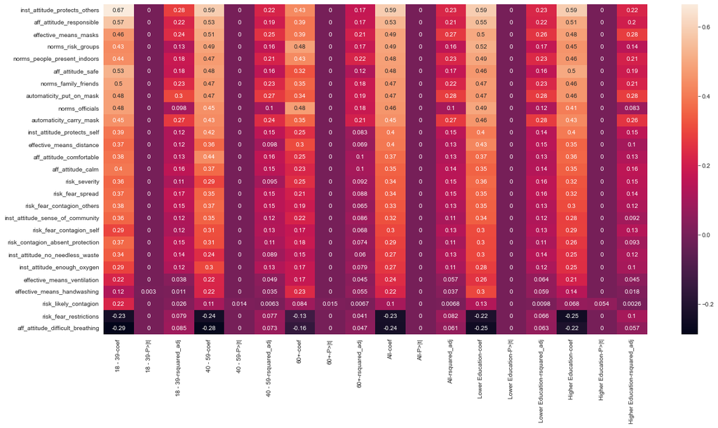

```python
_ = plt.figure(figsize=(20,10))
_ = sns.heatmap(data=all_ols_df.sort_values(by = ("All", "coef"), ascending=False),
               annot=True)
_ = plt.xlabel("")
```

So, the sample-level PCI is simply:

[Room for improvement] * [Weight]

Room for improvement is the distance of some centrality measure from a minimum or maximum value. The centrality measure we use in the tables in the analysis script is the mean; the minimum and maximum are the observed minimum and maximum. (you could also use e.g. scale min/max; or trimmed min/max; and you can also use median or trimmed mean etc). Whether you take the distance from the minimum or maximum depends on whether the determinant is positively or negatively associated to the criterion/target. If it's associated positively, you take the maximum (because 'increasing' the determinant increases the target), and if it's associated negatively, you take the minimum (because 'decreasing' the determinant increases the target).

The Weight is some indication of the strength of the association between the determinant and the criterion/target; e.g. the correlation or the proportion of explained variance.

The manual for the R function in the behaviorchange package is at https://r-packages.gitlab.io/behaviorchange/reference/potential_for_change.html

```python
bootstrap_sample_size = 1000
bootstrap_number = 100
```

```python
all_pcis_df = pd.DataFrame()
for i in range(0, bootstrap_number):
    # print(df.sample(n=bootstrap_sample_size, random_state=0 + i).index)
    tmp_pci_df = potential_for_change_index(data=df
                                            .sample(n=bootstrap_sample_size, random_state=0 + i)
                                            .drop(["demographic_age", "demographic_higher_education"], axis=1),
                                           features_list=features_list,
                                            target=target,
                                            minimum_measure = 'min',
                                            centrality_measure = 'mean',
                                            maximum_measure = 'max',
                                            weight_measure = 'r-value',
                                            scale_data = False,
                                            pci_heatmap = False,)
    all_pcis_df = pd.concat([all_pcis_df, tmp_pci_df["PCI"]], axis=1)
```

```python
all_pcis_df.columns = [f"PCI_{x}" for x in range(0, all_pcis_df.shape[1])]
```

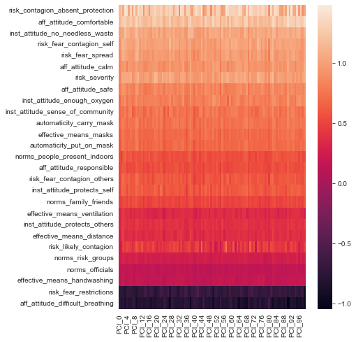

```python
_ = plt.figure(figsize=(6, 8))
_ = sns.heatmap(all_pcis_df.sort_values(by="PCI_0", ascending=False))
```

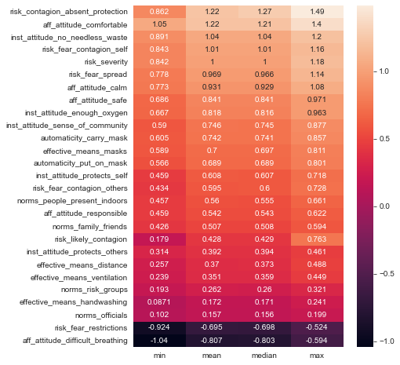

```python
_ = plt.figure(figsize=(6, 8))
_ = sns.heatmap(all_pcis_df.agg(["min", "mean", "median", "max"], axis=1).sort_values(by="mean", ascending=False),
               annot=True,
               fmt=".3g")
```

```python
all_pcis_df = pd.DataFrame()
for group in groups_dict:
    if type(groups_dict[group]) == list:
        tmp_df = df[df["demographic_age"].isin(groups_dict[group])]
    else:
        tmp_df = df[df["demographic_higher_education"] == groups_dict[group]]

    tmp_pci_df = potential_for_change_index(data=tmp_df.drop(["demographic_age", "demographic_higher_education"], axis=1),
                                           features_list=features_list,
                                            target=target,
                                            minimum_measure = 'min',
                                            centrality_measure = 'mean',
                                            maximum_measure = 'max',
                                            weight_measure = 'r-value',
                                            scale_data = True,
                                            pci_heatmap = False,)
    tmp_pci_df = tmp_pci_df.rename(columns={"PCI": f"PCI_{group}"})
    all_pcis_df = pd.concat([all_pcis_df, tmp_pci_df[f"PCI_{group}"]], axis=1)
```

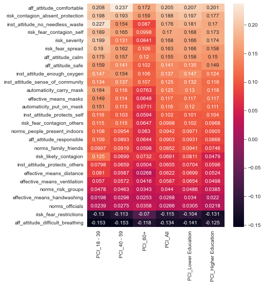

```python
# all_pcis_df
_ = plt.figure(figsize=(6, 8))
_ = sns.heatmap(all_pcis_df.sort_values(by="PCI_All", ascending=False),
               annot=True,
                fmt=".3g"
               )
```

```python
tmp_pci_df
```

|  | PCI_Higher Education | min | mean | max | r-value | p-value |
| --- | --- | --- | --- | --- | --- | --- |
| automaticity_carry_mask | 0.117922 | 0.0 | 0.769389 | 1.0 | 0.511347 | 3.212978e-71 |
| automaticity_put_on_mask | 0.110642 | 0.0 | 0.791231 | 1.0 | 0.529977 | 2.608476e-77 |
| inst_attitude_protects_self | 0.103801 | 0.0 | 0.736784 | 1.0 | 0.394355 | 1.647150e-40 |
| inst_attitude_protects_others | 0.059621 | 0.0 | 0.874327 | 1.0 | 0.474414 | 3.321665e-60 |
| inst_attitude_sense_of_community | 0.116430 | 0.0 | 0.616967 | 1.0 | 0.303969 | 6.005034e-24 |
| inst_attitude_enough_oxygen | 0.124163 | 0.0 | 0.615226 | 1.0 | 0.322690 | 6.077654e-27 |
| inst_attitude_no_needless_waste | 0.170189 | 0.0 | 0.500950 | 1.0 | 0.341026 | 4.351885e-30 |
| norms_family_friends | 0.074592 | 0.0 | 0.839348 | 1.0 | 0.464311 | 2.026669e-57 |
| norms_risk_groups | 0.038474 | 0.0 | 0.898860 | 1.0 | 0.380402 | 1.365162e-37 |
| norms_officials | 0.021821 | 0.0 | 0.924501 | 1.0 | 0.289022 | 1.042186e-21 |
| norms_people_present_indoors | 0.090478 | 0.0 | 0.804052 | 1.0 | 0.461745 | 9.984087e-57 |
| aff_attitude_comfortable | 0.200786 | 0.0 | 0.438272 | 1.0 | 0.357442 | 4.344677e-33 |
| aff_attitude_calm | 0.150455 | 0.0 | 0.619183 | 1.0 | 0.395085 | 1.148430e-40 |
| aff_attitude_safe | 0.149164 | 0.0 | 0.657961 | 1.0 | 0.436103 | 4.037628e-50 |
| aff_attitude_responsible | 0.086788 | 0.0 | 0.806743 | 1.0 | 0.449080 | 2.153540e-53 |
| effective_means_handwashing | 0.022008 | 0.0 | 0.840614 | 1.0 | 0.138079 | 6.894889e-06 |
| effective_means_masks | 0.117252 | 0.0 | 0.778727 | 1.0 | 0.529897 | 2.773695e-77 |
| effective_means_distance | 0.052379 | 0.0 | 0.836657 | 1.0 | 0.320667 | 1.311864e-26 |
| effective_means_ventilation | 0.049792 | 0.0 | 0.768123 | 1.0 | 0.214732 | 1.893904e-12 |
| risk_likely_contagion | 0.047910 | 0.0 | 0.193868 | 1.0 | 0.059431 | 5.385966e-02 |
| risk_contagion_absent_protection | 0.176651 | 0.0 | 0.424366 | 1.0 | 0.306881 | 2.121670e-24 |
| risk_severity | 0.173538 | 0.0 | 0.550491 | 1.0 | 0.386061 | 9.299078e-39 |
| risk_fear_spread | 0.157659 | 0.0 | 0.581671 | 1.0 | 0.376878 | 7.080169e-37 |
| risk_fear_contagion_self | 0.172541 | 0.0 | 0.528490 | 1.0 | 0.365933 | 1.035783e-34 |
| risk_fear_contagion_others | 0.096815 | 0.0 | 0.720798 | 1.0 | 0.346756 | 4.087183e-31 |
| aff_attitude_difficult_breathing | -0.125021 | 0.0 | 0.520418 | 1.0 | -0.240232 | 2.739089e-15 |
| risk_fear_restrictions | -0.130543 | 0.0 | 0.402184 | 1.0 | -0.324585 | 2.941561e-27 |